# Упражнение 5

Степанов Герман

24 Март 2021

## Вариант 26

1 Оценить стандартную ошибку модели для линейных регрессионных моделей из упражнения 4 (варианты ниже): а) со всеми объясняющими переменными; б) только с непрерывными объясняющими переменными:

- методом проверочной выборки с долей обучающей 50%;
- методом LOOCV;
- k-кратной кросс-валидацией с k=5 и k=10.

Выбрать лучшую модель по минимуму ошибки. Все ли методы кросс-валидации сходятся на одной и той же модели?

2 Оценить стандартные ошибки параметров лучшей модели регрессии методом бутстрепа. Вывести график остатков лучшей модели. Сравнить с оценками стандартных ошибок параметров по МНК.

### Описание переменных

Набор данных Auto содержит переменные:

mpg - миль на галлон

weight - Масса автомобиля (кг.)

displacement - Объем двигателя (куб. дюймов)

origin - Происхождение автомобиля (1. Американский, 2. Европейский, 3. Японский)

Размерность обучающей выборки: n = 392 строк, p = 4 объясняющих переменных. Зависимая переменная – mpg.

### Метод перекрёстной проверки

Рассмотрим данные с характеристиками автомобилей Auto из пакета ISLR. Скопируем таблицу во фрейм DF.auto для дальнейших манипуляций.

```r
my.seed <- 26
Auto <- subset(Auto, select = c(mpg, weight, displacement, horsepower, origin))
DF.auto <- Auto
head(DF.auto)
```

```
##   mpg weight displacement horsepower origin
## 1  18   3504          307        130      1
## 2  15   3693          350        165      1
## 3  18   3436          318        150      1
## 4  16   3433          304        150      1
## 5  17   3449          302        140      1
## 6  15   4341          429        198      1
```

## Oписательные статистики по переменным

```r
summary(DF.auto)
```

```
##       mpg            weight      displacement     horsepower        origin
##  Min.   : 9.00   Min.   :1613   Min.   : 68.0   Min.   : 46.0   Min.   :1.000
##  1st Qu.:17.00   1st Qu.:2225   1st Qu.:105.0   1st Qu.: 75.0   1st Qu.:1.000
##  Median :22.75   Median :2804   Median :151.0   Median : 93.5   Median :1.000
##  Mean   :23.45   Mean   :2978   Mean   :194.4   Mean   :104.5   Mean   :1.577
##  3rd Qu.:29.00   3rd Qu.:3615   3rd Qu.:275.8   3rd Qu.:126.0   3rd Qu.:2.000
##  Max.   :46.60   Max.   :5140   Max.   :455.0   Max.   :230.0   Max.   :3.000
```

```r
table(DF.auto$origin)
```

```
##
##   1   2   3
## 245  68  79
```

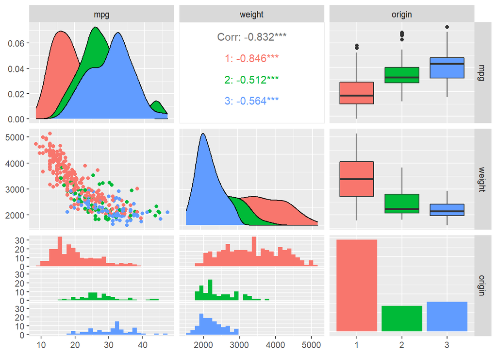

```r
# переводим дискретные количественные переменные в факторы
DF.auto$origin <- as.factor(DF.auto$origin)
# графики разброса, цвет -- количество цилиндров
ggpairs(DF.auto[, c(1, 2, 5)], ggplot2::aes(color = origin))
```

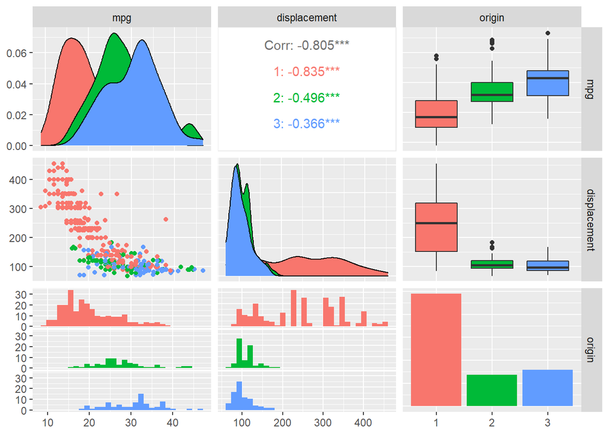

```r
ggpairs(DF.auto[, c(1, 3, 5)], ggplot2::aes(color = origin))
```

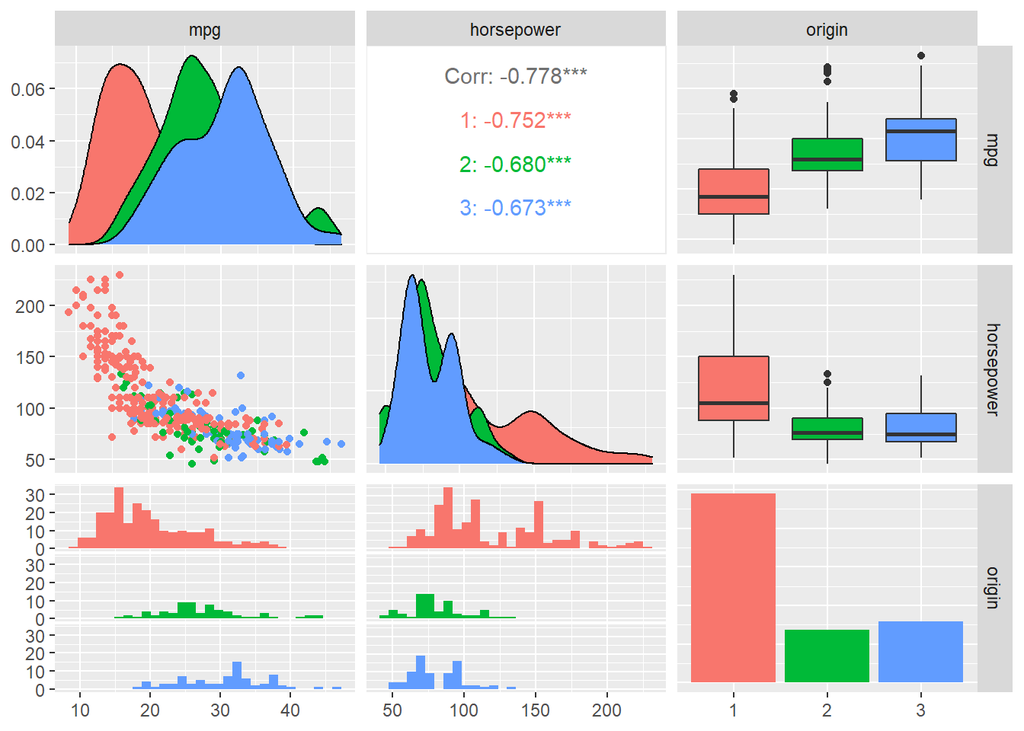

```r
ggpairs(DF.auto[, c(1, 4, 5)], ggplot2::aes(color = origin))
```

#### Только mpg ~ weight, mpg ~ displacement, mpg ~ horsepower

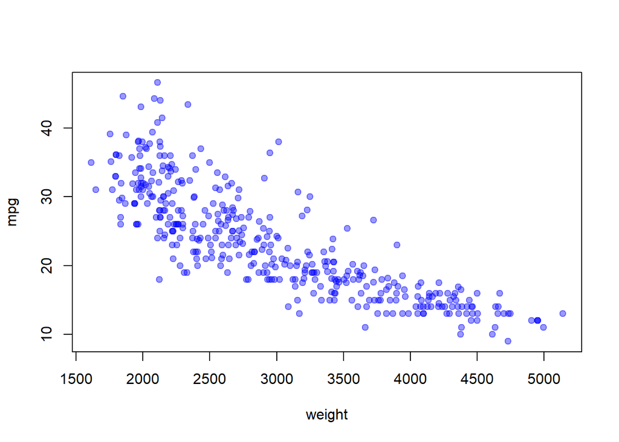

```r
plot(DF.auto$weight, DF.auto$mpg,
     xlab = 'weight', ylab = 'mpg', pch = 21,
     col = rgb(0, 0, 1, alpha = 0.4), bg = rgb(0, 0, 1, alpha = 0.4))
```

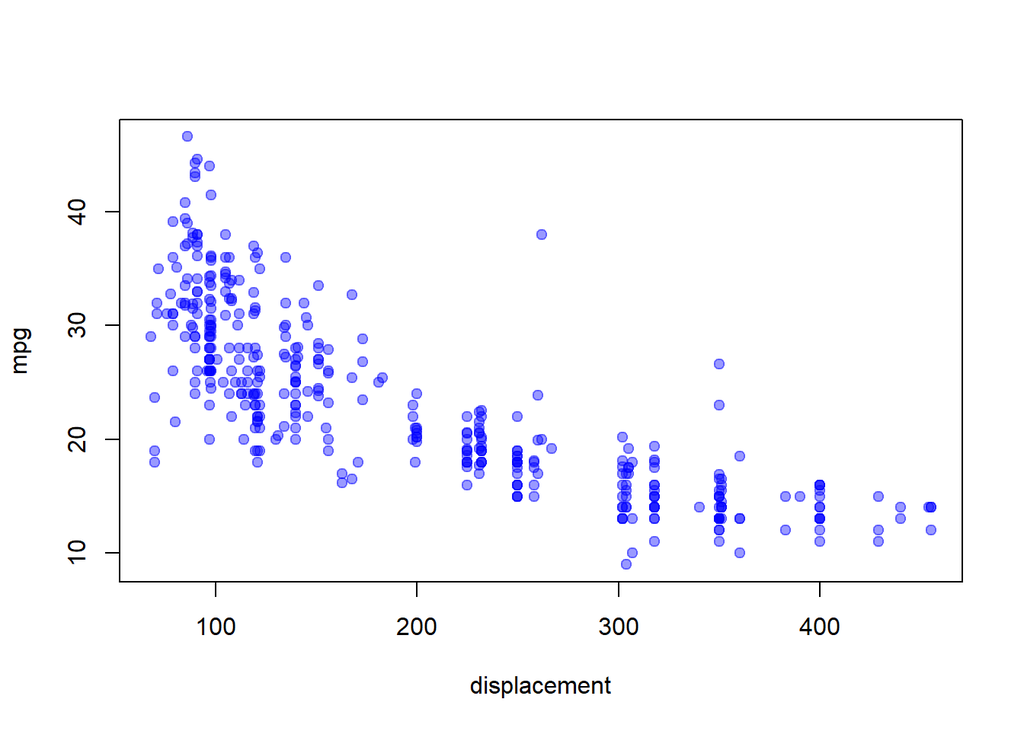

```r
plot(DF.auto$displacement, DF.auto$mpg,
     xlab = 'displacement', ylab = 'mpg', pch = 21,
     col = rgb(0, 0, 1, alpha = 0.4), bg = rgb(0, 0, 1, alpha = 0.4))
```

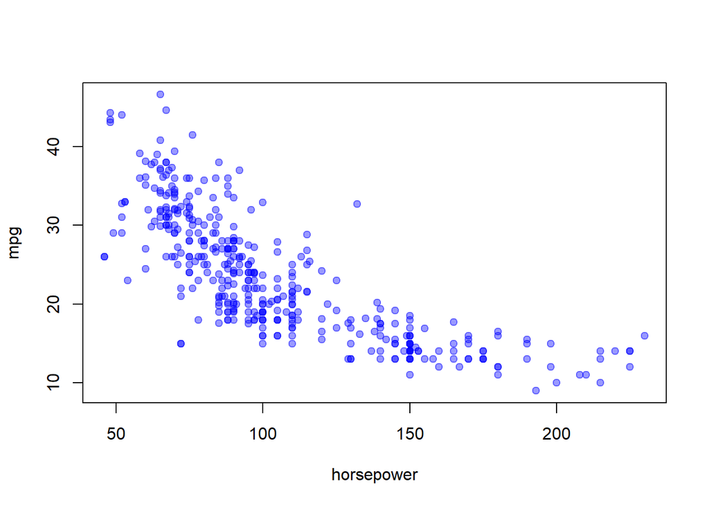

```r
plot(DF.auto$horsepower, DF.auto$mpg,
     xlab = 'horsepower', ylab = 'mpg', pch = 21,
     col = rgb(0, 0, 1, alpha = 0.4), bg = rgb(0, 0, 1, alpha = 0.4))
```

## Метод проверочной выборки

Он состоит в том, что мы отбираем одну тестовую выборку и будем считать на ней ошибку модели

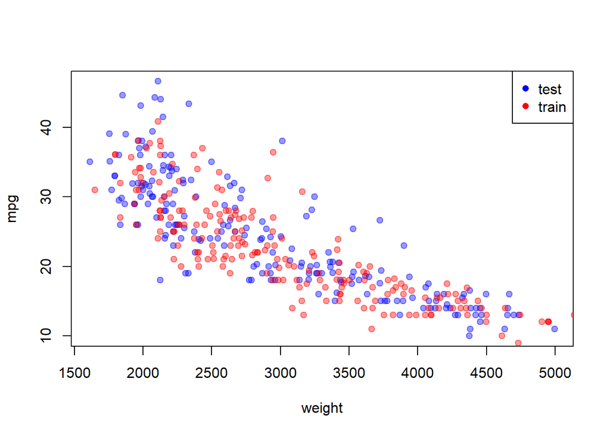

```r
# общее число наблюдений
n <- nrow(DF.auto)
# доля обучающей выборки
train.percent <- 0.5
# выбрать наблюдения в обучающую выборку
set.seed(my.seed)
inTrain <- sample(1:n, n * train.percent)
# фактические значения Y на тестовой выборке
y.test.fact <- DF.auto$mpg[-inTrain]
# рисуем разными цветами обучающую и тестовую
plot(DF.auto$weight[inTrain], DF.auto$mpg[inTrain],
     xlab = 'weight', ylab = 'mpg', pch = 21,
     col = rgb(0, 0, 1, alpha = 0.4), bg = rgb(0, 0, 1, alpha = 0.4))
points(DF.auto$weight[-inTrain], DF.auto$mpg[-inTrain],
       pch = 21, col = rgb(1, 0, 0, alpha = 0.4),
       bg = rgb(1, 0, 0, alpha = 0.4))
legend('topright',
       pch = c(16, 16), col = c('blue', 'red'), legend = c('test', 'train'))
```

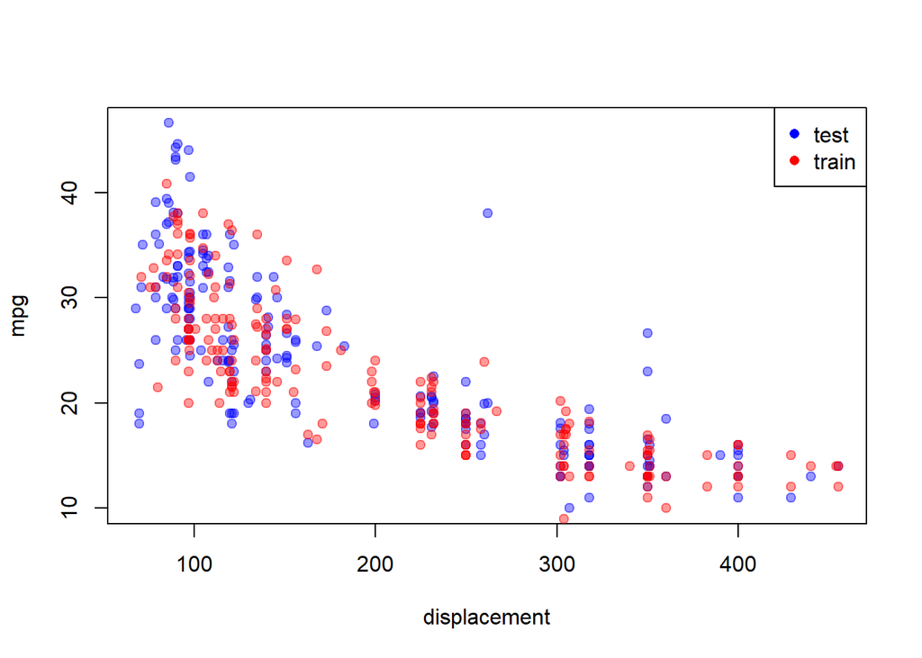

```r
plot(DF.auto$displacement[inTrain], DF.auto$mpg[inTrain],
     xlab = 'displacement', ylab = 'mpg', pch = 21,
     col = rgb(0, 0, 1, alpha = 0.4), bg = rgb(0, 0, 1, alpha = 0.4))
points(DF.auto$displacement[-inTrain], DF.auto$mpg[-inTrain],
       pch = 21, col = rgb(1, 0, 0, alpha = 0.4),
       bg = rgb(1, 0, 0, alpha = 0.4))
legend('topright',
       pch = c(16, 16), col = c('blue', 'red'), legend = c('test', 'train'))
```

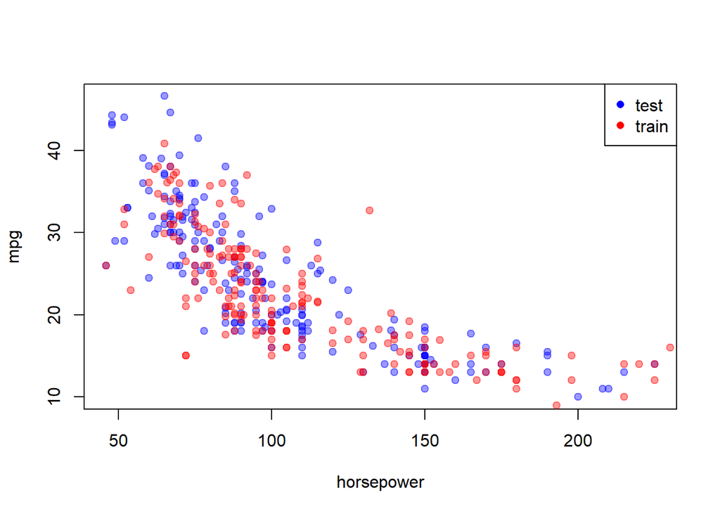

```r
plot(DF.auto$horsepower[inTrain], DF.auto$mpg[inTrain],
     xlab = 'horsepower', ylab = 'mpg', pch = 21,
     col = rgb(0, 0, 1, alpha = 0.4), bg = rgb(0, 0, 1, alpha = 0.4))
points(DF.auto$horsepower[-inTrain], DF.auto$mpg[-inTrain],
       pch = 21, col = rgb(1, 0, 0, alpha = 0.4),
       bg = rgb(1, 0, 0, alpha = 0.4))
legend('topright',
       pch = c(16, 16), col = c('blue', 'red'), legend = c('test', 'train'))
```

Построим модели для проверки точности со всеми объясняющими переменными.

Вид моделей:

$$mpg=f(weight + displacement + horsepower + origin)$$
Линейная модель:

$$mpg=β_0+β_1⋅weihgt +β_2 displacement +β_3 horsepower+ origin$$

```r
# присоединить таблицу с данными: названия стоблцов будут доступны напрямую
attach(DF.auto)
# подгонка модели на обучающей выборке
fit.lm.1_1 <- lm(mpg ~ weight + displacement + horsepower + origin, subset = inTrain)
# подгонка линейной модели на обучающей выборке
fit.lm.1_1 <- lm(mpg ~ weight + displacement + horsepower + origin,
               subset = inTrain)
# прогноз на тестовую
y.test.lm.1_1 <- predict(fit.lm.1_1, DF.auto[-inTrain, ])
# считаем MSE на тестовой выборке
MSE.lm.1_1 <- mean((y.test.fact - y.test.lm.1_1)^2)
# отсоединить таблицу с данными
detach(DF.auto)
# смотрим ошибку
MSE.lm.1_1
```

```
## [1] 17.93041
```

Строим квадратичную модель:

```r
# присоединить таблицу с данными: названия стоблцов будут доступны напрямую
attach(DF.auto)
# подгонка модели на обучающей выборке
fit.lm.2_1 <- lm(mpg ~ poly(weight, 2) + poly(displacement, 2) + poly(horsepower, 2) + origin, subset = inTrain)
# прогноз на тестовую
y.test.lm.2_1 <- predict(fit.lm.2_1, DF.auto[-inTrain, ])
# считаем MSE на тестовой выборке
MSE.lm.2_1 <- round(mean((y.test.fact - y.test.lm.2_1)^2), 2)
# отсоединить таблицу с данными
detach(DF.auto)
# смотрим ошибку
MSE.lm.2_1
```

```
## [1] 15.64
```